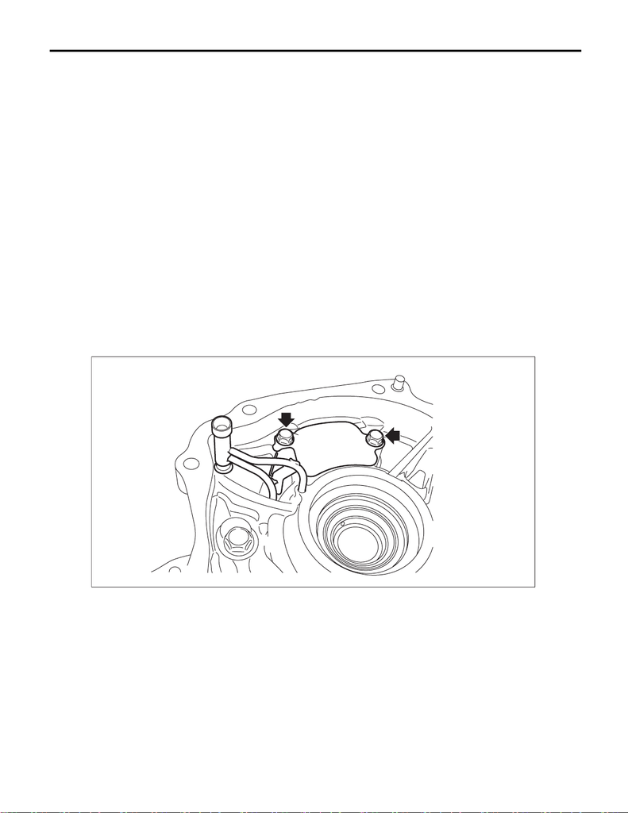

CVT(TR690)-292

Converter Case Cover

CONTINUOUSLY VARIABLE TRANSMISSION

47.Converter Case Cover

A: REMOVAL

1) Remove the transmission assembly from the vehicle. <Ref. to CVT(TR690)-56, REMOVAL, Automatic

Transmission Assembly.>

2) Remove the air breather hose. <Ref. to CVT(TR690)-136, REMOVAL, Air Breather Hose.>

3) Remove the oil pan and control valve body. <Ref. to CVT(TR690)-112, REMOVAL, Control Valve Body.>

4) Remove the transmission harness. <Ref. to CVT(TR690)-123, REMOVAL, Transmission Harness.>

5) Remove the extension case. <Ref. to CVT(TR690)-142, REMOVAL, Extension Case.>

6) Remove the rear drive shaft. <Ref. to CVT(TR690)-146, REMOVAL, Rear Drive Shaft.>

7) Remove the transfer clutch assembly. <Ref. to CVT(TR690)-151, REMOVAL, Transfer Clutch.>

8) Remove the center differential carrier. <Ref. to CVT(TR690)-154, REMOVAL, Center Differential Carrier.>

9) Remove the transfer reduction driven gear assembly. <Ref. to CVT(TR690)-158, REMOVAL, Transfer Re-

duction Driven Gear.>

10) Remove the intermediate case. <Ref. to CVT(TR690)-165, REMOVAL, Intermediate Case.>

11) Remove the forward clutch assembly. <Ref. to CVT(TR690)-181, REMOVAL, Forward Clutch Assem-

bly.>

12) Remove the transmission case. <Ref. to CVT(TR690)-212, REMOVAL, Transmission Case.>

13) Remove the primary pulley, secondary pulley and variator chain. <Ref. to CVT(TR690)-228, REMOVAL,

Primary Pulley and Secondary Pulley.>

14) Remove the drive pinion shaft assembly. <Ref. to CVT(TR690)-244, REMOVAL, Drive Pinion Shaft As-

sembly.>

15) Remove the oil stopper plate and lubrication pipe.

AT-05447

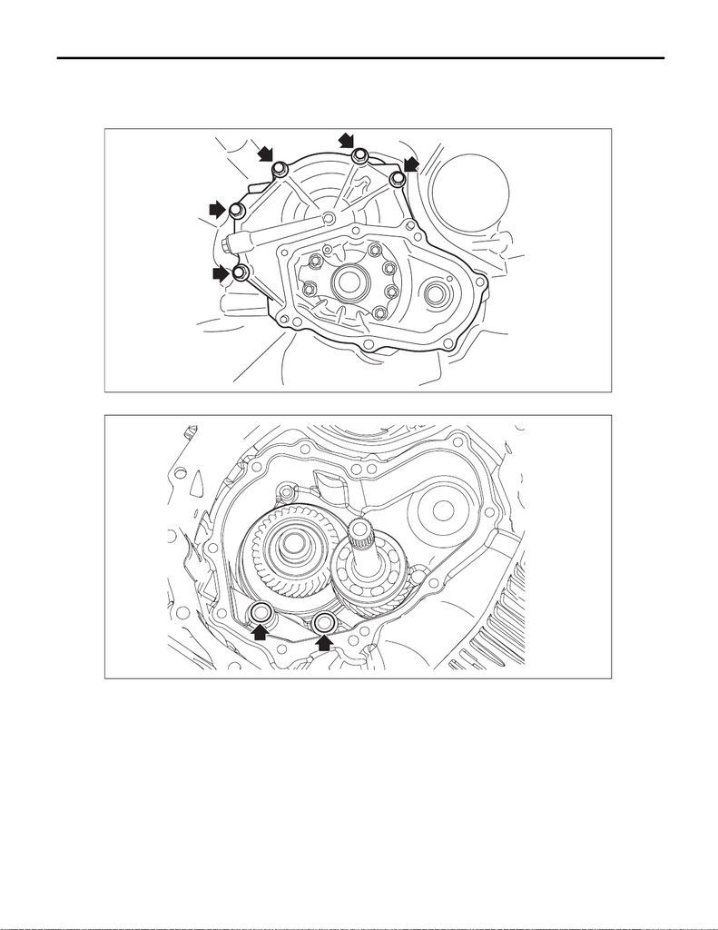

CVT(TR690)-293

Converter Case Cover

CONTINUOUSLY VARIABLE TRANSMISSION

16) Flip over the converter case.

17) Remove the oil pump chain cover and the oil pump chain. <Ref. to CVT(TR690)-285, REMOVAL, Oil

Pump Chain.>

18) Remove the converter case cover.

19) Remove the O-rings.

AT-05896

AT-07980

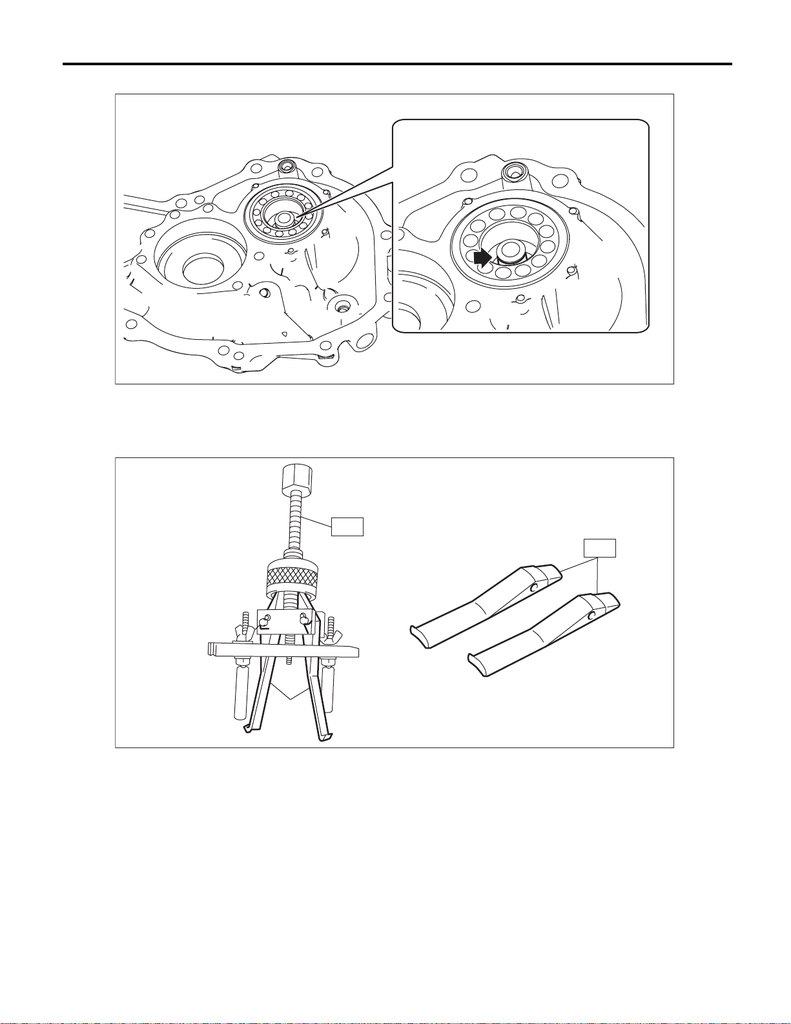

CVT(TR690)-294

Converter Case Cover

CONTINUOUSLY VARIABLE TRANSMISSION

20) Remove the seal ring from converter case cover.

21) Using the ST, remove the ball bearing from the converter case cover.

(1) Remove the claw of ST1, and attach the claw of ST2.

ST1 398527700 PULLER ASSY

ST2 18760AA000 CLAW

(A) Claw

AT-07981

AT-06447

(A)

ST1

ST2

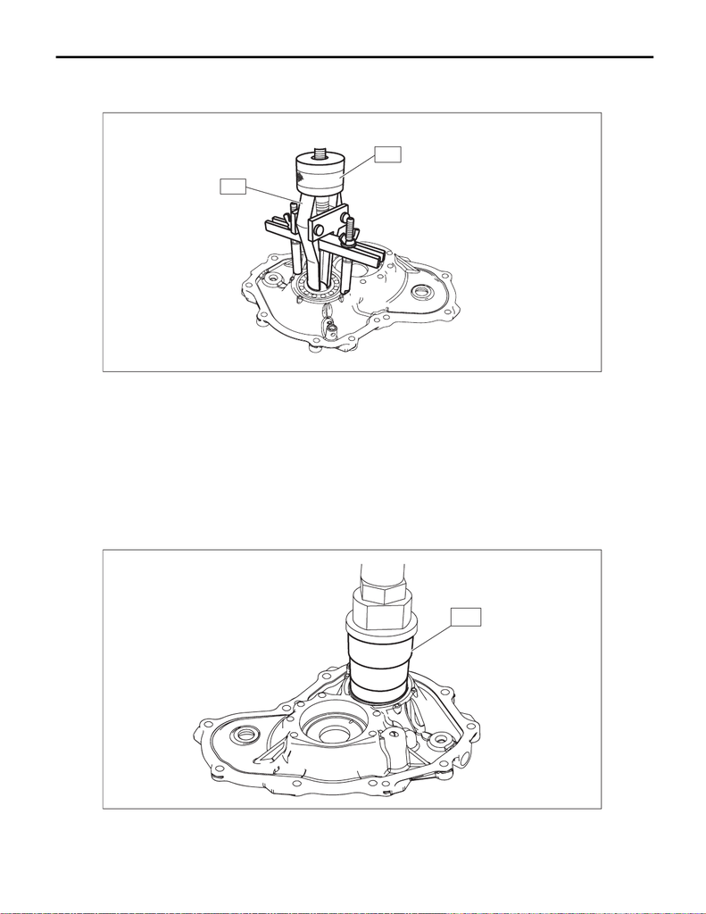

CVT(TR690)-295

Converter Case Cover

CONTINUOUSLY VARIABLE TRANSMISSION

(2) Using the ST, remove the ball bearing from the converter case cover.

ST1 398527700 PULLER ASSY

ST2 18760AA000 CLAW

B: INSTALLATION

1) Clean the mating surface of converter case cover and converter case.

2) Adjust the shims of front reduction drive gear and front reduction driven gear. <Ref. to CVT(TR690)-308,

ADJUSTMENT, Front Reduction Drive Gear.> <Ref. to CVT(TR690)-316, ADJUSTMENT, Front Reduction

Driven Gear.>

3) Apply CVTF to the selected shims and install on the bearing catch surface of the front reduction driven

gear.

4) Using the ST, install the ball bearing to the converter case cover.

NOTE:

Use a new ball bearing.

ST 499755602 PRESS SNAP RING

ST1

ST2

AT-07983

ST

AT-07982

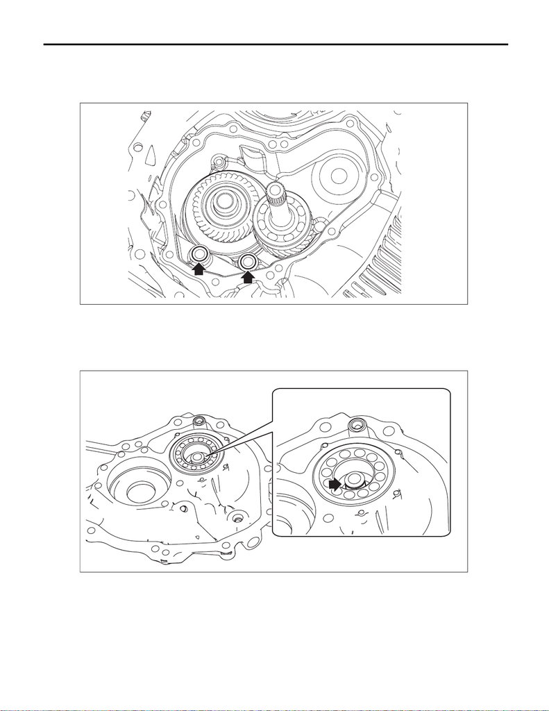

CVT(TR690)-296

Converter Case Cover

CONTINUOUSLY VARIABLE TRANSMISSION

5) Install the O-rings.

NOTE:

• Use new O-rings.

• Apply CVTF to the O-rings.

6) Apply CVTF to the selected shims and install on the bearing catch surface of the front reduction drive gear.

7) Install the seal ring to converter case cover.

NOTE:

• Use new seal rings.

• When installing the seal rings, do not expand the seal rings too much.

AT-07980

AT-07981

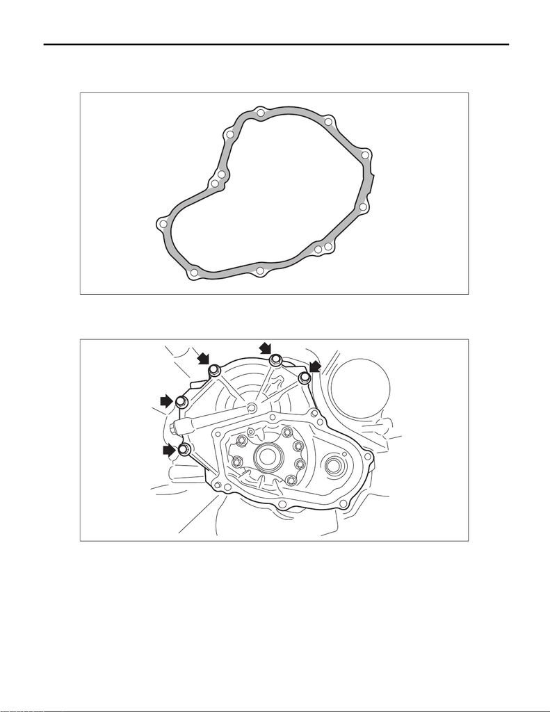

CVT(TR690)-297

Converter Case Cover

CONTINUOUSLY VARIABLE TRANSMISSION

8) Apply liquid gasket seamlessly to the mating surface of converter case cover.

Liquid gasket:

THREE BOND 1215B or equivalent

9) Install the converter case cover.

Tightening torque:

24 N·m (2.4 kgf-m, 17.7 ft-lb)

AT-05421

AT-05896

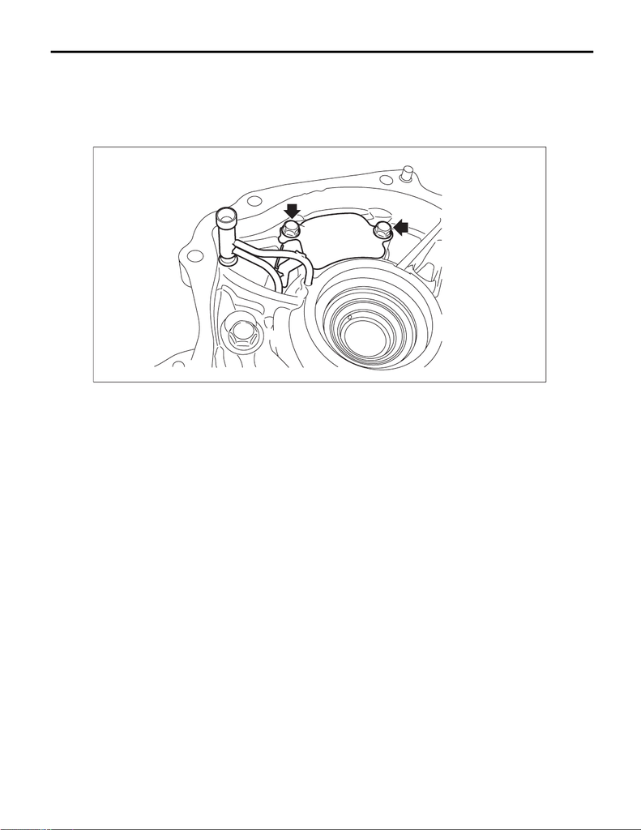

CVT(TR690)-298

Converter Case Cover

CONTINUOUSLY VARIABLE TRANSMISSION

10) Install the oil pump chain cover and the oil pump chain. <Ref. to CVT(TR690)-287, INSTALLATION, Oil

Pump Chain.>

11) Flip over the converter case cover.

12) Install the oil stopper plate and lubrication pipe.

Tightening torque:

9 N·m (0.9 kgf-m, 6.6 ft-lb)

13) Install the drive pinion shaft assembly. <Ref. to CVT(TR690)-246, INSTALLATION, Drive Pinion Shaft

Assembly.>

14) Install the primary pulley, secondary pulley and variator chain. <Ref. to CVT(TR690)-232, INSTALLA-

TION, Primary Pulley and Secondary Pulley.>

15) Install the transmission case. <Ref. to CVT(TR690)-214, INSTALLATION, Transmission Case.>

16) Install the forward clutch assembly. <Ref. to CVT(TR690)-182, INSTALLATION, Forward Clutch Assem-

bly.>

17) Install the intermediate case. <Ref. to CVT(TR690)-166, INSTALLATION, Intermediate Case.>

18) Install the transfer reduction driven gear assembly. <Ref. to CVT(TR690)-158, INSTALLATION, Transfer

Reduction Driven Gear.>

19) Install the center differential carrier. <Ref. to CVT(TR690)-155, INSTALLATION, Center Differential Car-

rier.>

20) Install the transfer clutch assembly. <Ref. to CVT(TR690)-151, INSTALLATION, Transfer Clutch.>

21) Install the rear drive shaft. <Ref. to CVT(TR690)-146, INSTALLATION, Rear Drive Shaft.>

22) Install the extension case. <Ref. to CVT(TR690)-143, INSTALLATION, Extension Case.>

23) Install the transmission harness. <Ref. to CVT(TR690)-125, INSTALLATION, Transmission Harness.>

24) Install the control valve body and oil pan. <Ref. to CVT(TR690)-116, INSTALLATION, Control Valve

Body.>

25) Install the air breather hose. <Ref. to CVT(TR690)-136, INSTALLATION, Air Breather Hose.>

26) Install the transmission assembly to the vehicle. <Ref. to CVT(TR690)-69, INSTALLATION, Automatic

Transmission Assembly.>

AT-05447

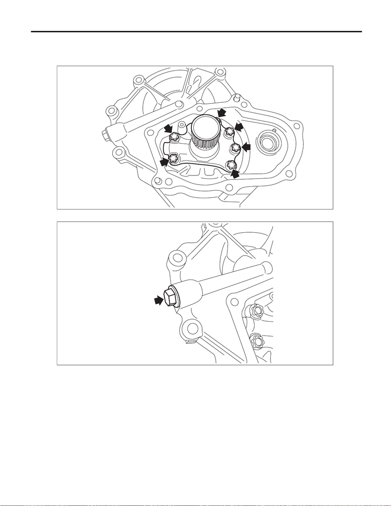

CVT(TR690)-299

Converter Case Cover

CONTINUOUSLY VARIABLE TRANSMISSION

C: DISASSEMBLY

1) Using ST, remove the center support COMPL.

ST 18270KA010 SOCKET (E16)

2) Remove the plug and O-ring.

AT-05422

AT-05423

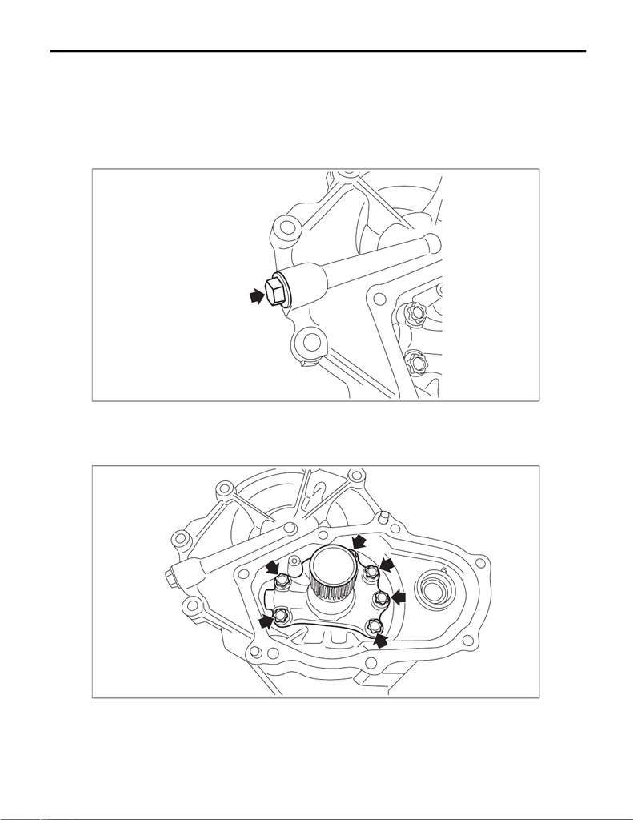

CVT(TR690)-300

Converter Case Cover

CONTINUOUSLY VARIABLE TRANSMISSION

D: ASSEMBLY

1) Install the plugs.

NOTE:

• Use new O-rings.

• Apply CVTF to the O-ring.

Tightening torque:

25 N·m (2.5 kgf-m, 18.4 ft-lb)

2) Using ST, install the center support COMPL.

ST 18270KA010 SOCKET (E16)

Tightening torque:

21.5 N·m (2.2 kgf-m, 15.9 ft-lb)

AT-05423

AT-05422

[figure not shown]

CVT(TR690)-301

Converter Case Cover

CONTINUOUSLY VARIABLE TRANSMISSION

E: INSPECTION

• Check for leakage of CVTF from the connection between converter case and converter case cover.

• Check there is no damage or cracks on the converter case cover.

F: ADJUSTMENT

When replacing the converter case cover, select the following shims.

• Select the shim for front reduction drive gear. <Ref. to CVT(TR690)-308, ADJUSTMENT, Front Reduction

Drive Gear.>

• Select the shim for front reduction driven gear. <Ref. to CVT(TR690)-316, ADJUSTMENT, Front Reduc-

tion Driven Gear.>